# Explorando licitações e contratos de merenda no Rio Grande do Sul

Neste relatório faremos uma breve exploração das licitações de merenda que aconteceram no Rio Grande do Sul entre os anos de 2017 e 2019. Iremos responder algumas perguntas como quantas licitações de merenda um município geralmente faz? Quantos são os concorrentes? O valor estimados dessas licitações é alto?

Foram selecionadas para análise todas as licitações que ocorreram entre 2017-02-08 e 2019-11-27. Todas são da modalidade CPP (Chamada Pública do Programa Nacional de Alimentação Escolar (PNAE)) e todas estão na fase de Adjudicadas que é a última fase da licitação na qual a Administração atribui ao Licitante vencedor o Objeto da Licitação.

## Quantas licitações são realizadas por ano?

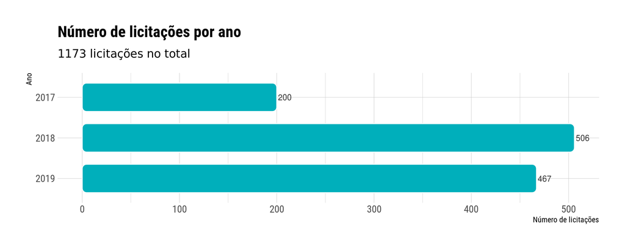

## Qual o período do ano em que as licitações são abertas?

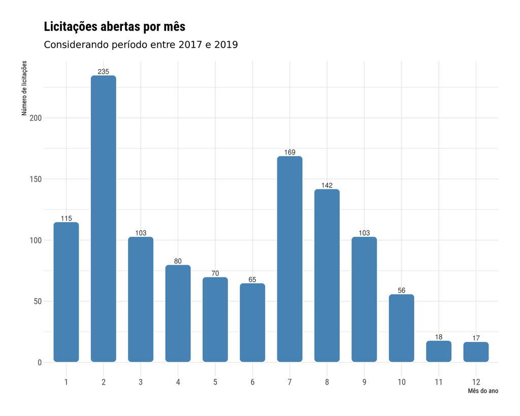

## Qual o período do ano em que as licitações são adjudicadas?

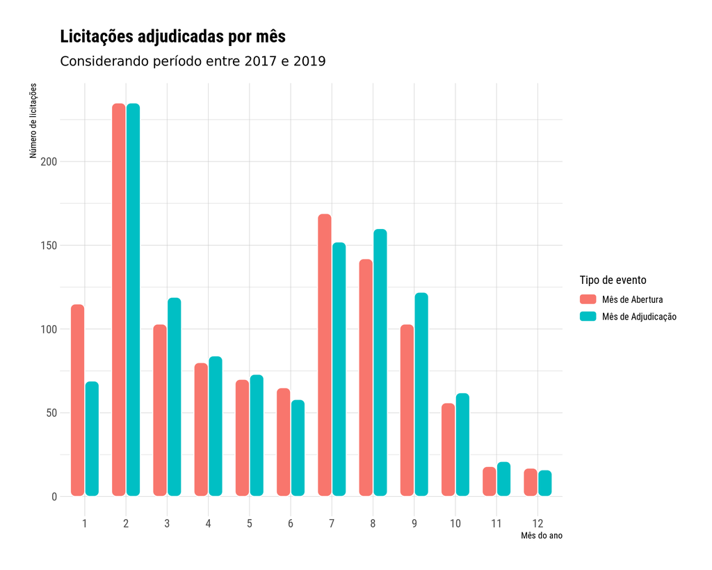

A mediana da diferência, em dias, entre a data de abertura e a data de adjudicação é de 6 dias. Sendo que 95% das licitações demora igual ou menos de 37 dias. A diferença máxima foi de 378 dias.

## Quantas licitações são realizadas por órgão?

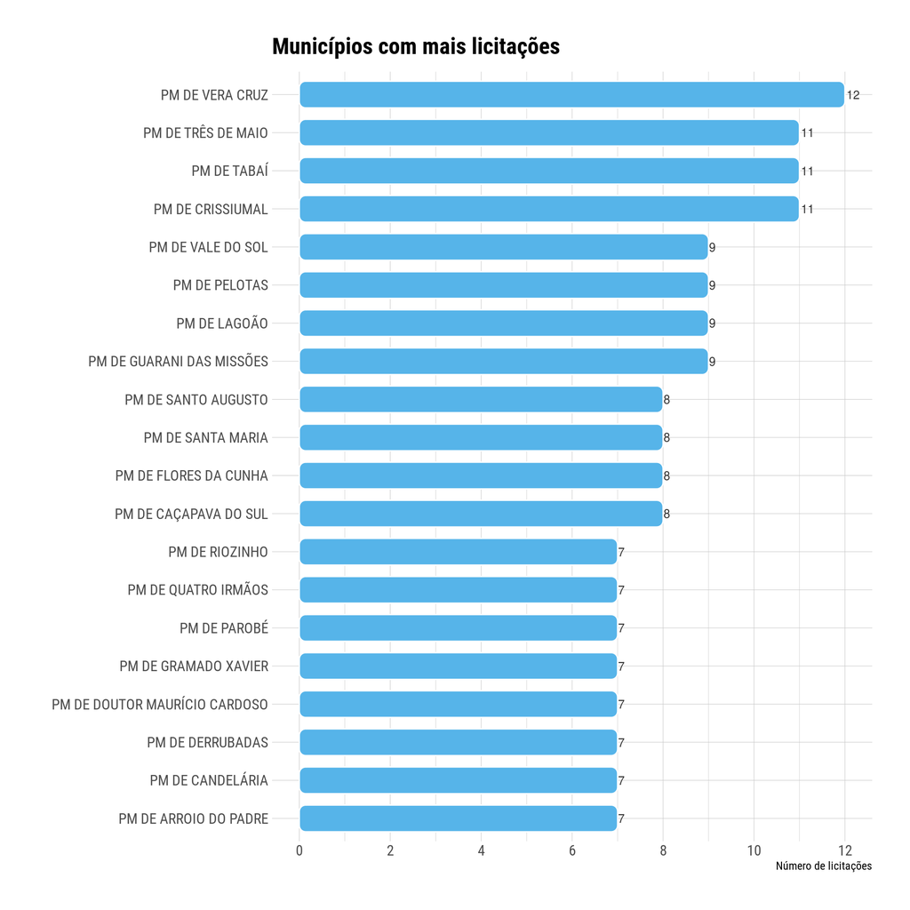

A mediana de licitações realizadas por órgão é de 4 licitações no período entre 2017 e 2019.

## Qual o valor das licitações de merenda?

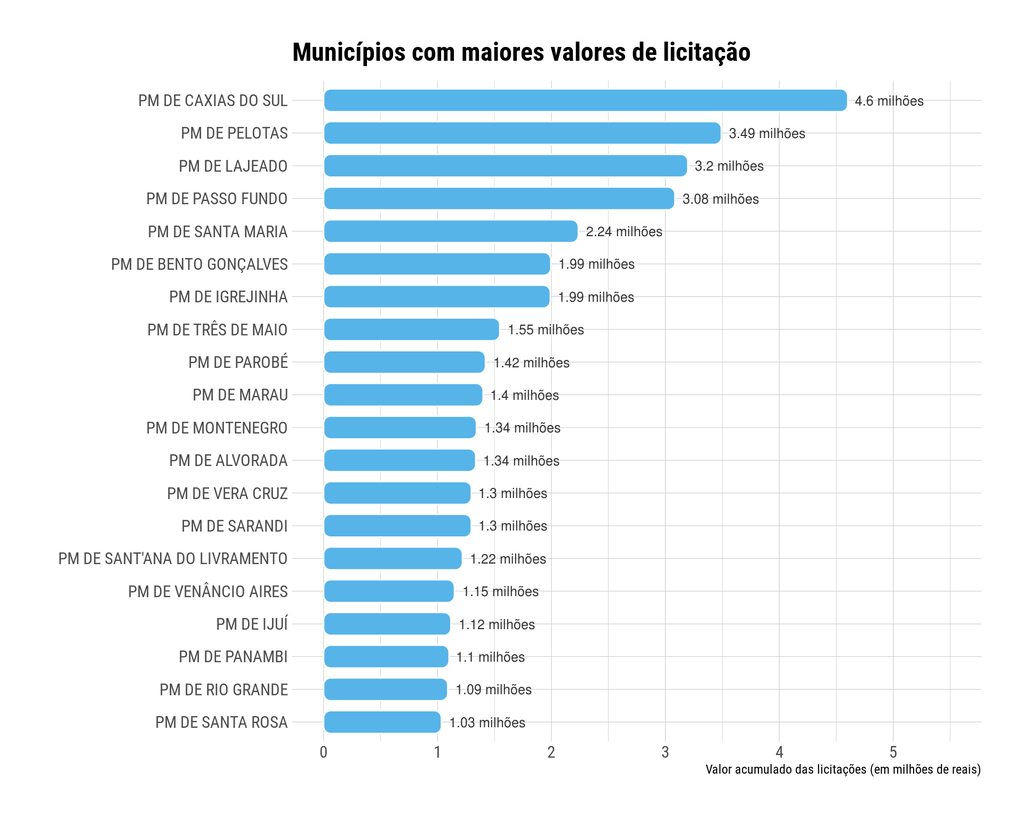

A mediana do valor das licitações é de 107399.68 reais.

As 5 licitações mais caras foram

| Município | Objeto | Abertura | Valor |
| --- | --- | --- | --- |
| PM DE CAXIAS DO SUL | Fornecimento de gêneros alimentícios diretamente de organizações da agricultura familiar e do empreendedor familiar rural. | 2018-12-05 | 1685601.65 |
| PM DE CAXIAS DO SUL | Fornecimento de gêneros alimentícios diretamente de organizações da agricultura familiar e do empreendedor familiar rural. | 2019-06-06 | 1486654.42 |
| PM DE CAXIAS DO SUL | Fornecimento de gêneros alimentícios diretamente de organizações da agricultura familiar e do empreendedor familiar rural. | 2018-06-18 | 1429406.38 |
| PM DE ALVORADA | Aquisição de gêneros alimentícios oriundos da agricultura familiar e empreendedor familiar rural, através de Chamamento Público, para atender a legislação nº 11.94712009 e Resolução noº2612013 do FNDE… | 2019-04-17 | 1335665 |
| PM DE LAJEADO | CHAMADA PÚBLICA PARA AQUISIÇÃO DE GÊNEROS ALIMENTÍCIOS DESTINADOS A ATENDIMENTO DA ALIMENTAÇÃO DOS ESCOLARES DO MUNICÍPIO. | 2019-04-30 | 1134466.1 |

## Quantos concorrentes participam de uma licitação?

A mediana do número de licitações que um fornecedor participa (com uma proposta) é de 2 licitações.

Os fornecedores com maior número de participações são:

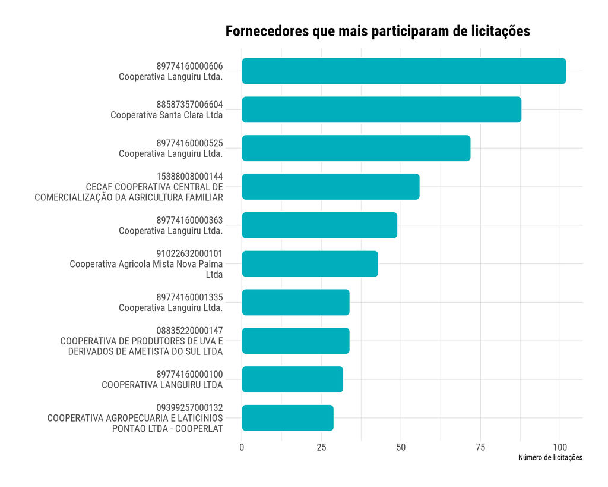